# R per l’analisi statistica multivariata

Rappresentazioni grafiche

# I dati `dde`

In questa lezione ci occuperemo di rappresentazioni grafiche di dati reali. Per fare questo, ci serviremo dei dataset chiamati `dde` e `titanic`.

## Importazione dei dati

Per un campione di `2312` donne in gravidanza, viene misurato il `DDE`, ovvero una sostanza connessa al DDT, presente nel siero materno durante il terzo trimestre della gravidanza.

La variabile `GAD` (Gestational Age at Delivery) misura invece a quale giorno della gravidanza è avvenuto il parto.

```r
path <- "https://tommasorigon.github.io/introR/data/dde.csv"
dde <- read.table(path, header = TRUE) # Scarica il file da internet

str(dde)
'data.frame':   2312 obs. of  2 variables:
 $ DDE: num  24.6 15.6 54.8 15 33.5 ...
 $ GAD: num  292 289 252 285 281 ...
```

## Distribuzione di frequenza

```r
breaks <- 18 * (0:10) # Definizione degli intervalli. Usiamo 10 intervalli di lunghezza 18.
dde$DDE_discretized <- cut(dde$DDE, breaks = breaks) # Creazione di una variabile divisa per intervalli

head(dde$DDE_discretized)
[1] (18,36] (0,18]  (54,72] (0,18]  (18,36] (18,36]
10 Levels: (0,18] (18,36] (36,54] (54,72] (72,90] (90,108] (108,126] (126,144] ... (162,180]
```

Le frequenze assolute si ottengono quindi usando il comando `table` applicato alla variabile divisa in intervalli.

Le frequenze relative e cumulate si ottengono invece utilizzando comandi noti.

```r
# Frequenze assolute
freq_ass <- table(dde$DDE_discretized)

# Frequenze relative
freq_rel <- freq_ass / sum(freq_ass)

# Frequenze relative cumulate
freq_rel_cum <- cumsum(freq_rel)
```

## Rappresentazione grafica delle frequenze

Raccogliamo quindi i risultati ottenuti al punto precedente in una matrice ed usiamo il comando `kable` per una migliore resa grafica.

```r
tab <- cbind(freq_ass, freq_rel, freq_rel_cum)
colnames(tab) <- c(
  "Frequenze assolute",
  "Frequenze relative",
  "Frequenze relative cumulate"
)

# Per ottenere una migliore resa grafica, si usa il pacchetto knitr
library(knitr)
kable(tab, digits = 3) # digits = 3 sono le cifre da riportare
```

|  | Frequenze assolute | Frequenze relative | Frequenze relative cumulate |
| --- | --- | --- | --- |
| (0,18] | 641 | 0.277 | 0.277 |
| (18,36] | 1070 | 0.463 | 0.740 |
| (36,54] | 373 | 0.161 | 0.901 |
| (54,72] | 125 | 0.054 | 0.955 |
| (72,90] | 54 | 0.023 | 0.979 |
| (90,108] | 29 | 0.013 | 0.991 |
| (108,126] | 9 | 0.004 | 0.995 |
| (126,144] | 6 | 0.003 | 0.998 |
| (144,162] | 3 | 0.001 | 0.999 |
| (162,180] | 2 | 0.001 | 1.000 |

## Boxplot

Una prima rappresentazione grafica è costituita dal boxplot. In **R** questa si ottiene semplicemente col comando `boxplot`.

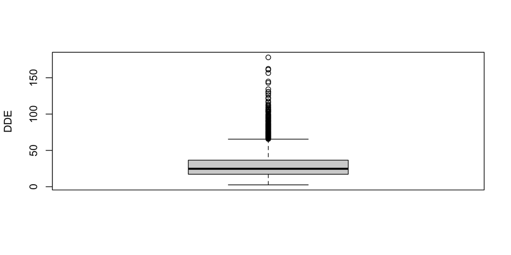

```r
boxplot(dde$DDE, ylab = "DDE") # ylab = "DDE" serve per inserire la legenda
```

## Istogramma

Un **istogramma** è una rappresentazione grafica delle frequenze assolute (oppure delle densità), relativa a intervalli specificati.

**Nota**. Il comando `hist` sceglie autonomamente la posizione ed il numero degli intervalli.

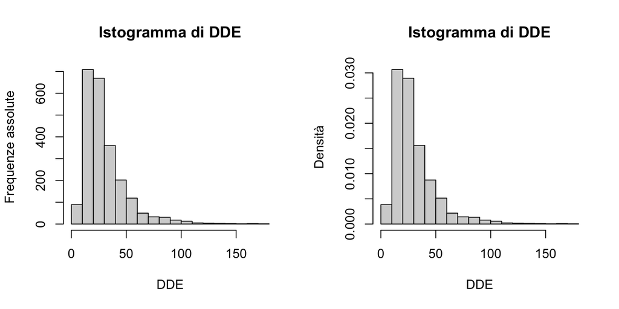

```r
par(mfrow = c(1, 2)) # Divide il grafico in due parti

# Primo grafico, frequenze assolute
hist(dde$DDE,
  freq = TRUE,
  main = "Istogramma di DDE",
  xlab = "DDE",
  ylab = "Frequenze assolute"
)

# Secondo grafico, densità
hist(dde$DDE,
  freq = FALSE,
  main = "Istogramma di DDE",
  xlab = "DDE",
  ylab = "Densità"
)
```

## Istogramma, numero di intervalli

Quando si rappresenta un istogramma il numero di intervalli va scelto con cura. Troppi intervalli producono un grafico con troppo rumore. Viceversa, pochi intervalli rischiano di nascondere il messaggio contenuto nei dati.

Sebbene **R** scelga in automatico il numero di intervalli, possiamo modificarne il numero e la posizione la posizione a nostro piacimento.

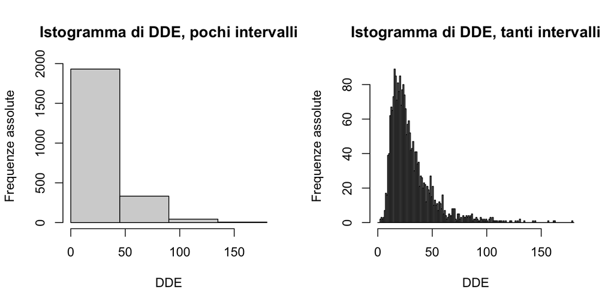

```r
par(mfrow = c(1, 2))

# Primo grafico, pochi intervalli
breaks <- 45 * (0:4) # Definizione degli intervalli
hist(dde$DDE,
  freq = TRUE,
  breaks = breaks,
  main = "Istogramma di DDE, pochi intervalli",
  xlab = "DDE",
  ylab = "Frequenze assolute"
)

# Secondo grafico, troppi intervalli
breaks <- 0:180 # Definizione degli intervalli
hist(dde$DDE,
  freq = TRUE,
  breaks = breaks,
  main = "Istogramma di DDE, tanti intervalli",
  xlab = "DDE",
  ylab = "Frequenze assolute"
)
```

## Istogramma, intervalli non equispaziati

Gli intervalli possono anche essere scelti non equispaziati. Tuttavia, in questo caso, non è corretto usare l’opzione `freq = TRUE`.

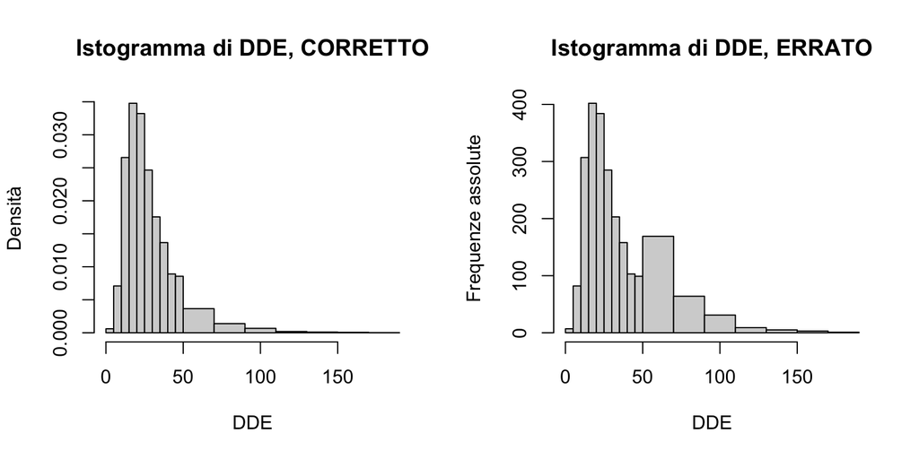

```r
par(mfrow = c(1, 2))

# GRAFICO CORRETTO
breaks <- c(5 * 0:10, 70, 90, 110, 130, 150, 170, 190) # Definizione degli intervalli
hist(dde$DDE,
  freq = FALSE,
  breaks = breaks,
  main = "Istogramma di DDE, CORRETTO",
  xlab = "DDE",
  ylab = "Densità"
)

# GRAFICO ERRATO
breaks <- c(5 * 0:10, 70, 90, 110, 130, 150, 170, 190) # Definizione degli intervalli
hist(dde$DDE,
  freq = TRUE,
  breaks = breaks,
  main = "Istogramma di DDE, ERRATO",
  xlab = "DDE",
  ylab = "Frequenze assolute"
)
Warning in plot.histogram(r, freq = freq1, col = col, border = border, angle = angle, : the AREAS in
the plot are wrong -- rather use 'freq = FALSE'
```

Fortunatamente, **R** restituisce un `warning`, ovvero un avvertimento, suggerendo di non usare l’opzione `freq=TRUE` in questo caso.

## Funzione di ripartizione

**R** permette di calcolare la funzione di ripartizione empirica dei dati tramite la funzione `ecdf()` (*empirical cumulative distribution function*).

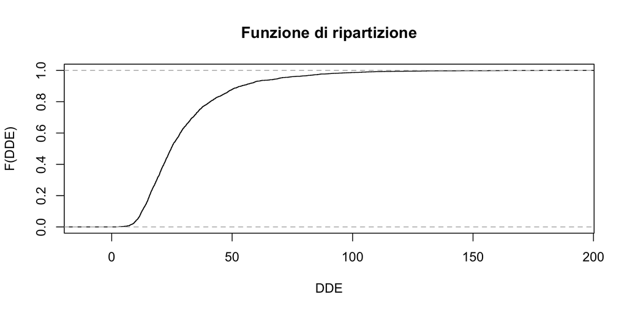

```r
plot(ecdf(dde$DDE),
  main = "Funzione di ripartizione",
  xlab = "DDE",
  ylab = "F(DDE)"
)
```

## Scatter-plot

Una rappresentazione grafica utile nel caso di vogliano rappresentare due variabili continue, è il cosiddetto diagramma a dispersione (scatterplot).

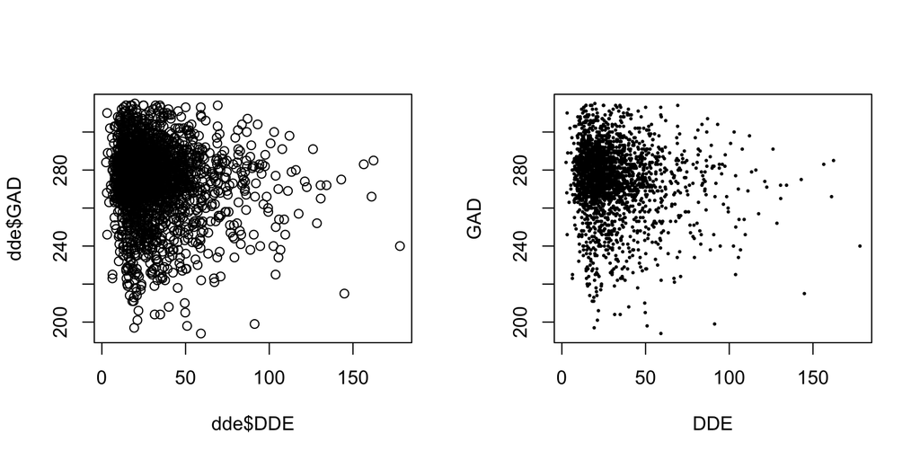

```r
par(mfrow = c(1, 2))

# Primo grafico
plot(dde$DDE, dde$GAD)

# Secondo grafico
plot(dde$DDE, dde$GAD,
  xlab = "DDE",
  ylab = "GAD",
  cex = 0.4, # Opzione per ridurre leggermente la dimensione dei punti
  pch = 16 # Cambia la forma dei punti
)
```

# Tabelle di contingenza

## Dati del titanic

I dati `titanic` fanno riferimento al tragico incidente navale avvenuto nel 1912. L’opzione `sep = ","` indica che i dati sono separati da una virgola.

```r
path <- "https://tommasorigon.github.io/introR/data/titanic.csv"
titanic <- read.table(path, header = TRUE, sep = ",", stringsAsFactors = TRUE) # Scarica il file da internet

str(titanic)
'data.frame':   1316 obs. of  2 variables:
 $ Salvato: Factor w/ 2 levels "No","Si": 2 2 2 2 2 2 2 2 2 2 ...
 $ Classe : Factor w/ 3 levels "I","II","III": 1 1 1 1 1 1 1 1 1 1 ...
```

Come fatto precedentemente, otteniamo le frequenze (assolute e relative) per la variabile classe.

```r
freq_ass <- table(titanic$Classe)
freq_rel <- freq_ass / sum(freq_ass)

tab <- cbind(freq_ass, freq_rel)
colnames(tab) <- c(
  "Frequenze assolute",
  "Frequenze relative"
)

kable(tab, digits = 3)
```

|  | Frequenze assolute | Frequenze relative |
| --- | --- | --- |
| I | 325 | 0.247 |
| II | 285 | 0.217 |
| III | 706 | 0.536 |

## Diagramma a barre

Il diagramma a barre è una rappresentazione grafica delle frequenze (assolute o relative), per variabili qualitative. In **R** è possibile ottenerlo tramite il comando `barplot`.

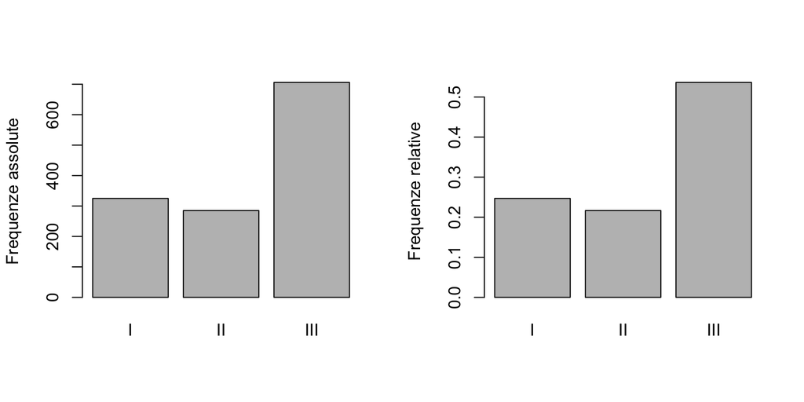

```r
par(mfrow = c(1, 2))
barplot(freq_ass, ylab = "Frequenze assolute") # Grafico frequenze assolute
barplot(freq_rel, ylab = "Frequenze relative") # Grafico frequenze relative
```

## Tabella a doppia entrata

La **tabella a doppia entrata** viene utilizzata per rappresentare una **distribuzione di frequenza congiunta** di due variabili.

Rappresentiamo qui di seguito la tabella che mette i relazioni si sopravvissuti `Salvato`, con la classe di appartenenza `Classe`, del dataset `titanic`.

```r
tab <- table(titanic$Salvato, titanic$Classe)
kable(tab)
```

|  | I | II | III |
| --- | --- | --- | --- |
| No | 122 | 167 | 528 |
| Si | 203 | 118 | 178 |

Possiamo anche aggiungere le frequenze assolute marginali come segue:

```r
tab_margins <- addmargins(tab)
kable(tab_margins)
```

|  | I | II | III | Sum |
| --- | --- | --- | --- | --- |
| No | 122 | 167 | 528 | 817 |
| Si | 203 | 118 | 178 | 499 |
| Sum | 325 | 285 | 706 | 1316 |

### Frequenze relative congiunte e relative marginali

Le **frequenze relative congiunte** si ottengono dividendo le frequenze congiunte assolute per il totale delle osservazioni. Pertanto, in **R** eseguiamo

```r
tab_rel <- prop.table(tab) # Comando alternativo: table(tab) / sum(tab)
kable(tab_rel, digits = 3)
```

|  | I | II | III |
| --- | --- | --- | --- |
| No | 0.093 | 0.127 | 0.401 |
| Si | 0.154 | 0.090 | 0.135 |

Esattamente come nel caso precedente, possiamo aggiungere le frequenze relative marginali.

```r
tab_rel_margins <- addmargins(tab_rel)
kable(tab_rel_margins)
```

|  | I | II | III | Sum |
| --- | --- | --- | --- | --- |
| No | 0.0927052 | 0.1268997 | 0.4012158 | 0.6208207 |
| Si | 0.1542553 | 0.0896657 | 0.1352584 | 0.3791793 |
| Sum | 0.2469605 | 0.2165653 | 0.5364742 | 1.0000000 |

## Diagramma a barre per tabelle a doppia entrata

A partire dalle tabelle a doppia entrata mostrate, è possibile rappresentare graficamente le distribuzioni di frequenza per mettere in evidenza la relazione tra le due variabili, utilizzando i diagrammi a barre accostate e sovrapposte.

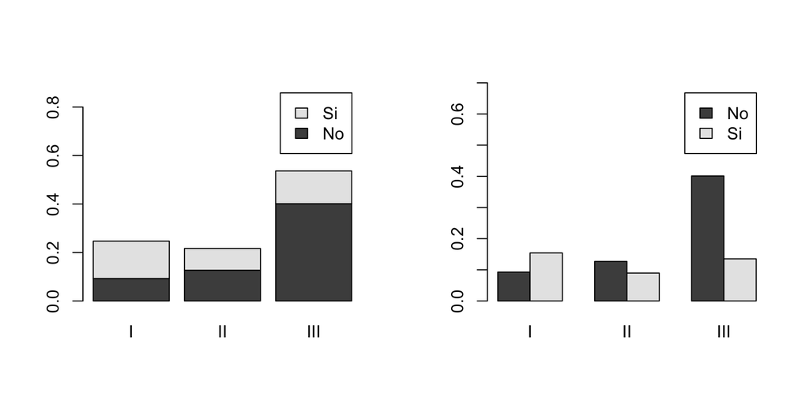

```r
par(mfrow = c(1, 2))
barplot(tab_rel,
  legend = rownames(tab_rel),
  ylim = c(0, 0.9)
)

barplot(tab_rel,
  beside = TRUE,
  legend = rownames(tab_rel),
  ylim = c(0, 0.7)
)
```

## Frequenze condizionate

Le **frequenze subordinate (o condizionate)** per riga o per colonna rappresentano la distribuzione di frequenze relative di una variabile per una fissata modalità dell’altra variabile. Esse permettono di identificare facilmente eventuali relazioni tra le variabili.

```r
# Frequenze condizionate 1
tab_cond1 <- addmargins(prop.table(tab, 1), 2)
kable(tab_cond1, digits = 3)
```

|  | I | II | III | Sum |
| --- | --- | --- | --- | --- |
| No | 0.149 | 0.204 | 0.646 | 1 |
| Si | 0.407 | 0.236 | 0.357 | 1 |

```r
# Frequenze condizionate 2
tab_cond2 <- addmargins(prop.table(tab, 2), 1)
kable(tab_cond2, digits = 3)
```

|  | I | II | III |
| --- | --- | --- | --- |
| No | 0.375 | 0.586 | 0.748 |
| Si | 0.625 | 0.414 | 0.252 |
| Sum | 1.000 | 1.000 | 1.000 |

Da quest’ultima tabella è decisamente evidente che i viaggiatori della I classe hanno ricevuto al momento del disastro un trattamento preferenziale.

Otteniamo infine il grafico delle precedenti tabelle.

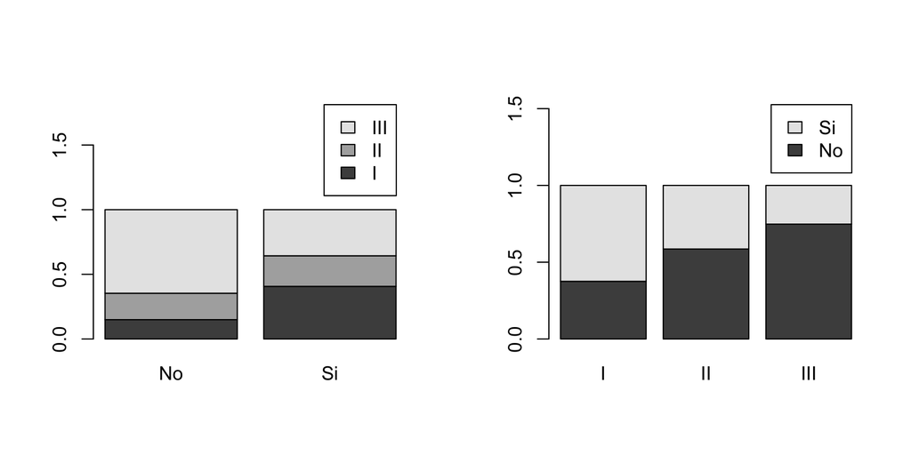

```r
par(mfrow = c(1, 2))
barplot(t(prop.table(tab, 1)),
  legend = colnames(tab),
  ylim = c(0, 1.9)
)

barplot(prop.table(tab, 2),
  legend = rownames(tab),
  ylim = c(0, 1.6)
)
```